# Woolfolk EC422 PS2 Writeup

Author

Jackson Woolfolk

Published

October 16, 2026

GitHub repo: https://github.com/Jackson-Woolfolk/ec422_ps2_woolfolk

## Data

First six rows of the raw data (long format).

| symbol | date | price |
| --- | --- | --- |
| UNRATE | 1976-01-01 | 7.9 |
| UNRATE | 1976-02-01 | 7.7 |
| UNRATE | 1976-03-01 | 7.6 |
| UNRATE | 1976-04-01 | 7.7 |
| UNRATE | 1976-05-01 | 7.4 |
| UNRATE | 1976-06-01 | 7.6 |

## Wrangling Steps

I renamed ‘price’ to ‘unemployment_rate’ and added a readable ‘region’ label for each series. Because of the fall 2025 government shutdown, the October 2025 value is missing, so I replaced it with the September 2025 value within each region. I also computed the month-over-month change in the unemployment rate, measured in percentage points. The tables below summarize the results.

Summary Statistics: Full Sample (1976-2025)

| Region | Mean Rate (%) | Min Rate (%) | Max Rate (%) |
| --- | --- | --- | --- |
| California | 7.07 | 3.8 | 16.1 |
| New York | 6.35 | 3.8 | 16.7 |
| Oregon | 6.66 | 3.4 | 13.7 |
| Texas | 5.85 | 3.4 | 12.8 |
| United States | 6.05 | 3.4 | 14.8 |

Summary Statistics: Recent Sample (2015 Onward)

| Region | Mean Rate (%) | Min Rate (%) | Max Rate (%) |
| --- | --- | --- | --- |
| California | 5.63 | 3.8 | 16.1 |
| New York | 5.10 | 3.8 | 16.7 |
| Oregon | 4.75 | 3.4 | 13.7 |
| Texas | 4.58 | 3.4 | 12.8 |
| United States | 4.62 | 3.4 | 14.8 |

Largest Month-over-Month Unemployment Increases (Excluding 2020)

| symbol | date | unemployment_rate | region | unemployment_rate_change |
| --- | --- | --- | --- | --- |
| TXUR | 2009-05-01 | 7.6 | Texas | 1.1 |
| ORUR | 2008-12-01 | 8.9 | Oregon | 0.7 |
| ORUR | 2008-11-01 | 8.2 | Oregon | 0.7 |
| ORUR | 2009-01-01 | 9.6 | Oregon | 0.7 |
| ORUR | 1980-03-01 | 7.4 | Oregon | 0.6 |
| UNRATE | 1980-04-01 | 6.9 | United States | 0.6 |

Largest Month-over-Month Unemployment Decreases (Excluding 2020)

| symbol | date | unemployment_rate | region | unemployment_rate_change |
| --- | --- | --- | --- | --- |
| UNRATE | 1983-07-01 | 9.4 | United States | -0.7 |
| NYUR | 2021-09-01 | 6.2 | New York | -0.6 |
| ORUR | 1977-05-01 | 7.8 | Oregon | -0.5 |
| CAUR | 2021-07-01 | 7.4 | California | -0.5 |
| CAUR | 2021-09-01 | 6.5 | California | -0.5 |
| NYUR | 2021-07-01 | 7.0 | New York | -0.5 |
| UNRATE | 2010-12-01 | 9.3 | United States | -0.5 |
| UNRATE | 2014-04-01 | 6.2 | United States | -0.5 |
| UNRATE | 2021-07-01 | 5.4 | United States | -0.5 |

## Visualization

library(ggplot2)

library(forcats)

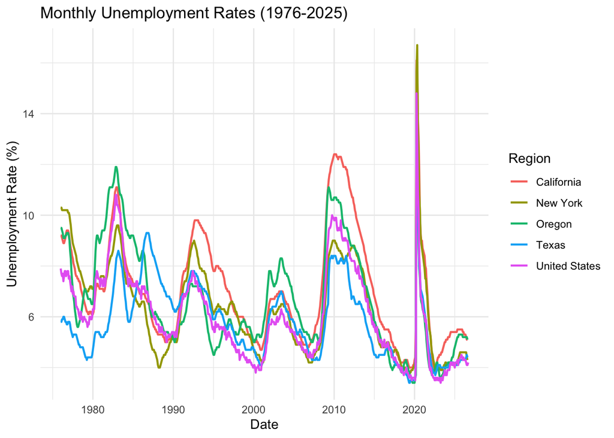

Monthly unemployment rate for the U.S. and four states, one line per region.

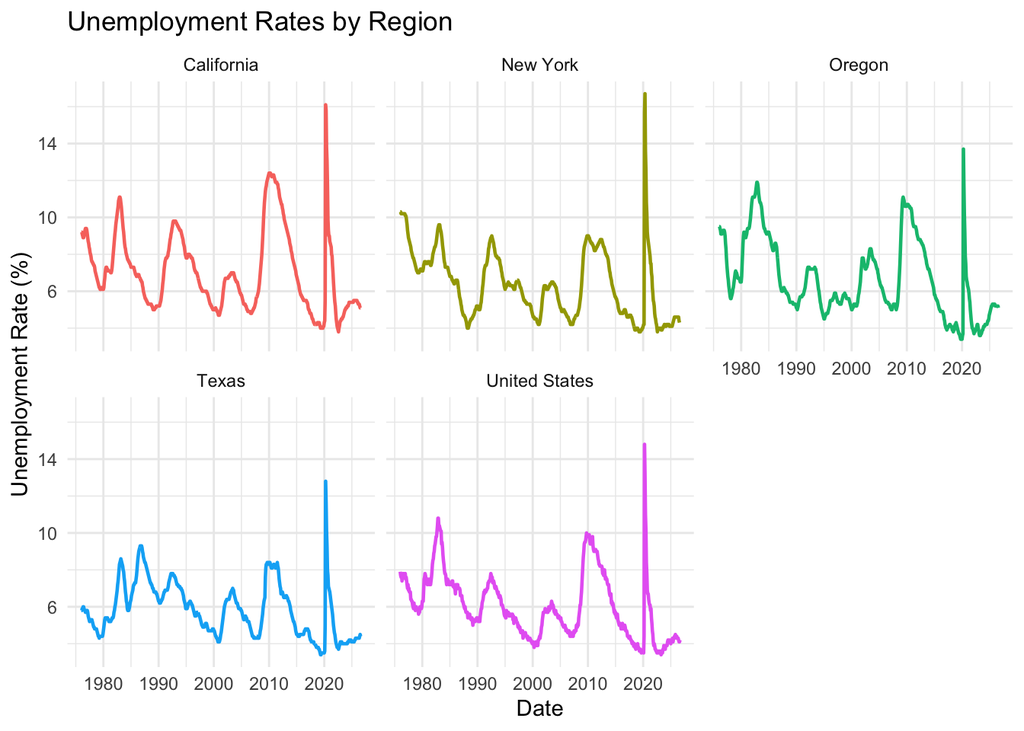

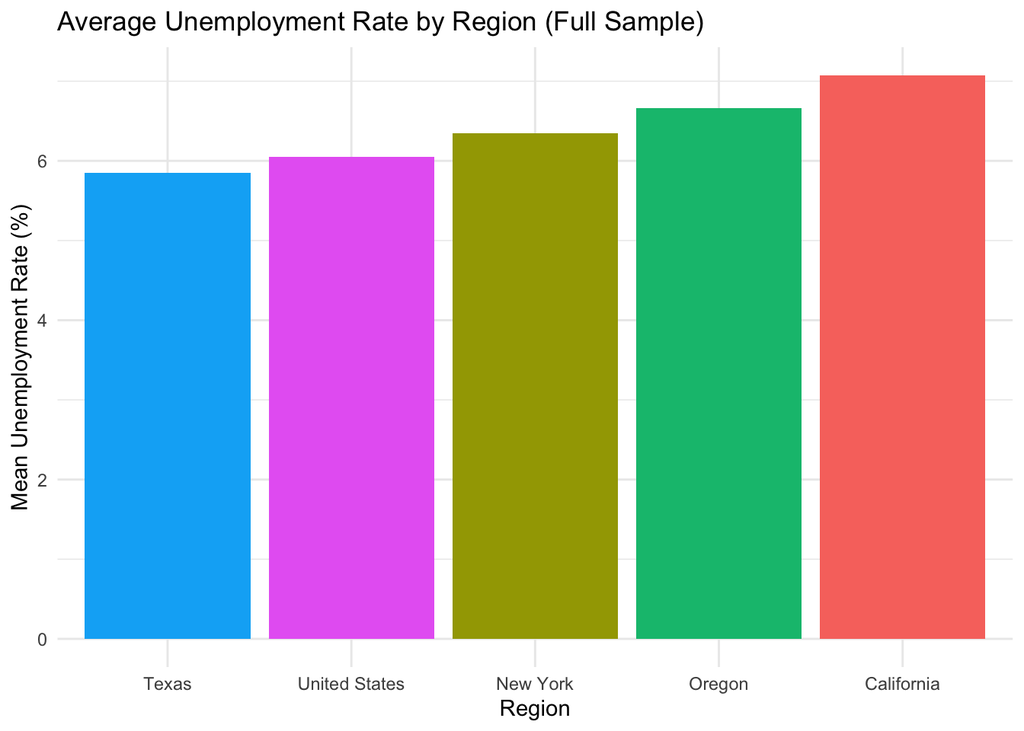

Mean unemployment rate by region over the full sample, ordered from lowest to highest.

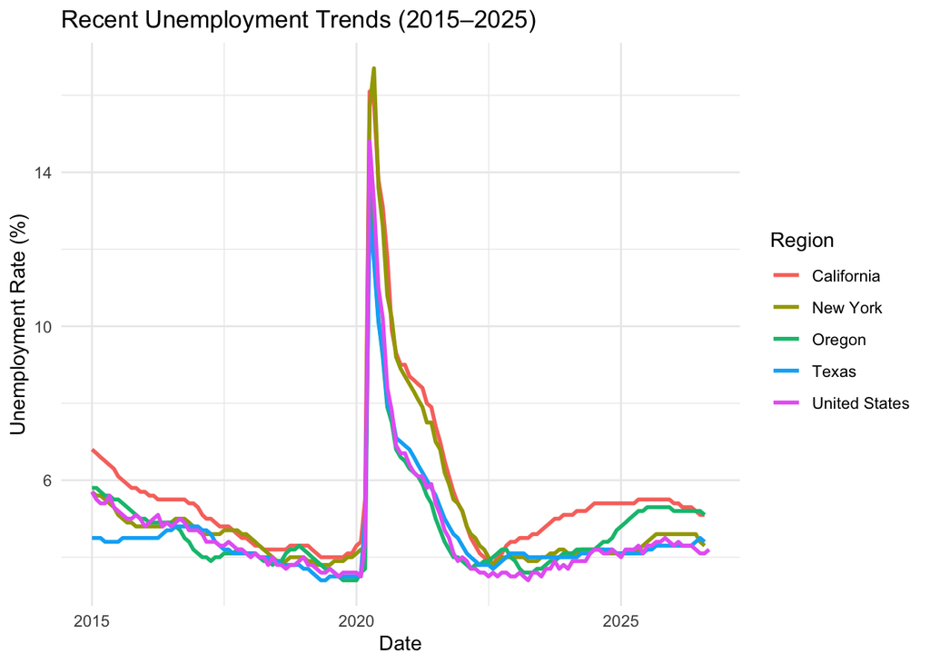

Unemployment rates since January 2015, higthlighting the COVID-19 spike and recovery between regions.

## My Graph

I chose to look at trends in state unemployment rates against each other, and used recent data so I could visualize the state’s reactions to the Covid-19 pandemic. This helps distinguish what states were able to recover faster than others after the pandemic caused a massive spike in unemployment.

## Final Reflection

The ggplot part felt the most straightforward once I started, because it became pretty easy to understand exactly what I was pulling and working with from the dataset. What tripped me up was the setup around the code. My first commits and pushes to GitHub kept failing with permission errors until I figured out how personal access tokens and cached credentials in my computer work. In Quarto, I also had trouble with backticks and chunk options: a single misplaced backtick or a ‘#|’ line in the wrong spot kept my code from running and just added to the confusion. There were a few times I needed help from Claude to run through my code for errors, but it showed me what to look for as I troubleshoot. I feel much more comfortable with the Git workflow now, especially committing in small steps with specific messages and pushing as I go instead of saving everything for the end.